# Course assignment for ‘Statistical Computing’ course

It can be seen that there is only one root in each of the corresponding 25 intervals, and within the interval, the following dichotomy method is adopted to find the root:

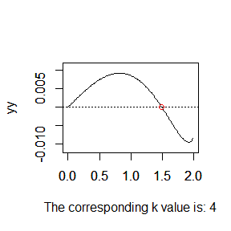

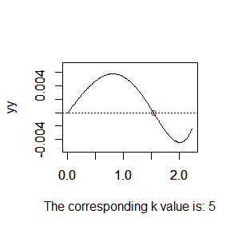

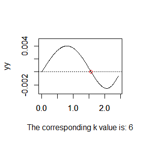

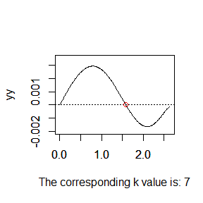

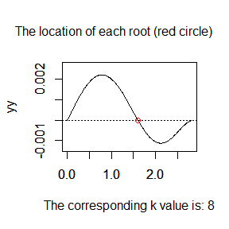

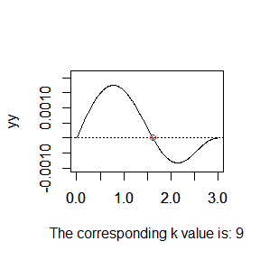

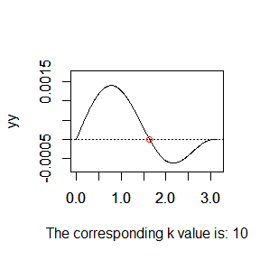

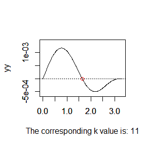

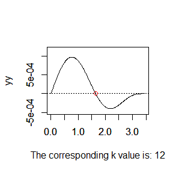

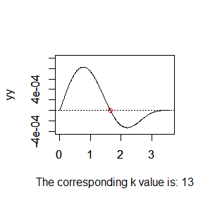

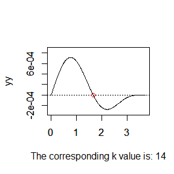

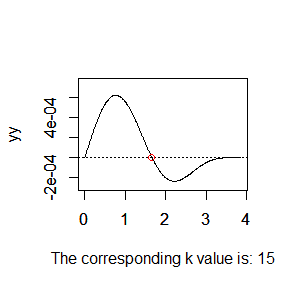

[13 more figures not shown]

```r
tF<-function(x,n){
   exp(lgamma((n+1)/2)-lgamma(n/2))*(1+x^2/n)^(-(n+1)/2)/(sqrt(n*pi))
}
KKK<-c(4:25,100,500,1000)
tt<-numeric(length(KKK))#Storage root
n<-numeric(length(KKK))
for (k in  1:length(KKK)){
   kk<-KKK[k]
   l<-0.01
   x1<-l#The left endpoint of the interval where the root is
   x2<-sqrt(kk)-l#The right endpoint of the interval where the root is
   barr<-10^(-6)#The threshold value
   y<-numeric(2)

   while (abs(x1-x2)>barr){
      tt[k]<-(x1+x2)/2#The midpoint of the interval

      al<-sqrt((x1)^2*(kk-1)/(kk-(x1)^2))
      bl<-sqrt((x1)^2*kk/(kk+1-(x1)^2))

      cl<-sqrt((tt[k])^2*(kk-1)/(kk-(tt[k])^2))
      dl<-sqrt((tt[k])^2*kk/(kk+1-(tt[k])^2))

      ala<-integrate(tF,lower=al,upper=Inf,n=(kk-1))
      blb<-integrate(tF,lower=bl,upper=Inf,n=kk)

      cla<-integrate(tF,lower=cl,upper=Inf,n=(kk-1))
      dlb<-integrate(tF,lower=dl,upper=Inf,n=kk)
      y[1]<-ala[1]$value-blb[1]$value
      y[2]<-cla[1]$value-dlb[1]$value
      if(y[1]*y[2]<=0){
         x2<-tt[k]
      }
      else{
         x1<-tt[k]
      }
      n[k]<-n[k]+1
   }
}

tty<-numeric(length(tt))


for (dd in 1:5){
   l<-5*(dd-1)+1
   KK<-KKK[l:(l+4)]
   #par(mfrow=c(1,5))
   for (k in  1:length(KK)){
      kk<-KK[k]
      ll<-0.01
      xx<-seq(0,sqrt(kk)-ll,by=ll)
      yy<-numeric(length(xx))
      for (p in 1:length(xx)){
         pp<-xx[p]
         l1<-sqrt(pp^2*(kk-1)/(kk-pp^2))
         l2<-sqrt(pp^2*kk/(kk+1-pp^2))
         la<-integrate(tF,lower=l1,upper=Inf,n=(kk-1))
         lb<-integrate(tF,lower=l2,upper=Inf,n=kk)
         yy[p]<-la[1]$value-lb[1]$value
      }

      tt1<-sqrt(tt[l+k-1]^2*(kk-1)/(kk-tt[l+k-1]^2))
      tt2<-sqrt(tt[l+k-1]^2*kk/(kk+1-tt[l+k-1]^2))
      tta<-integrate(tF,lower=tt1,upper=Inf,n=(kk-1))
      ttb<-integrate(tF,lower=tt2,upper=Inf,n=kk)
      tty[l+k-1]<-tta[1]$value-ttb[1]$value

      plot(xx,yy,'l',xlab="",xlim=c(0,sqrt(kk)),ylim=c(min(yy)*1.2,max(yy)*1.2))
      abline(h=0,lty=3)
      par(new=TRUE)
      plot(tt[l+k-1],tty[l+k-1],'b',col='red',xlab=paste("The corresponding k value is:",kk),ylab="",xlim=c(0,sqrt(kk)),ylim=c(min(yy)*1.2,max(yy)*1.2))
   }
    if(dd==1){
    mtext("The location of each root (red circle)", side =3, line = -2.5, outer = TRUE)
     }
}
```

```r
for (ind in 1:length(tt)){
   print(paste('when k=',KKK[ind],',the corresponding root is:',tt[ind]))
}
```

```
## [1] "when k= 4 ,the corresponding root is: 1.49210244178772"
## [1] "when k= 5 ,the corresponding root is: 1.53355888662201"
## [1] "when k= 6 ,the corresponding root is: 1.56274442057473"
## [1] "when k= 7 ,the corresponding root is: 1.58442948472815"
## [1] "when k= 8 ,the corresponding root is: 1.60118273087501"
## [1] "when k= 9 ,the corresponding root is: 1.61451706409454"
## [1] "when k= 10 ,the corresponding root is: 1.62538299831247"
## [1] "when k= 11 ,the corresponding root is: 1.63440848889216"
## [1] "when k= 12 ,the corresponding root is: 1.64202536340088"
## [1] "when k= 13 ,the corresponding root is: 1.64853886381836"
## [1] "when k= 14 ,the corresponding root is: 1.65417454469598"
## [1] "when k= 15 ,the corresponding root is: 1.65909606037013"
## [1] "when k= 16 ,the corresponding root is: 1.66343349933624"
## [1] "when k= 17 ,the corresponding root is: 1.66728311523575"
## [1] "when k= 18 ,the corresponding root is: 1.67072404702613"
## [1] "when k= 19 ,the corresponding root is: 1.67381765920448"
## [1] "when k= 20 ,the corresponding root is: 1.67661335956311"
## [1] "when k= 21 ,the corresponding root is: 1.67915346493629"
## [1] "when k= 22 ,the corresponding root is: 1.68147064512166"
## [1] "when k= 23 ,the corresponding root is: 1.68359412750352"
## [1] "when k= 24 ,the corresponding root is: 1.68554567271062"
## [1] "when k= 25 ,the corresponding root is: 1.68734700918198"
## [1] "when k= 100 ,the corresponding root is: 1.72059946894646"
## [1] "when k= 500 ,the corresponding root is: 1.72974479827132"
## [1] "when k= 1000 ,the corresponding root is: 1.73089755927409"
```

## answer

The likelihood function for the complete data is $L=(p^2)^{n_{AA}}(q^2)^{n_{BB}}(r^2)^{n_{OO}}(2pr)^{n_{AO}}(2qr)^{n_{BO}}(2pq)^{n_{AB}}$ and know that under the observation data,$n_{AA}\sim B(n_A.,\frac{p^2}{p^2+2pr}),n_{BB}\sim B(n_B.,\frac{q^2}{q^2+2qr}),$

for $\forall i>0$ let $M=n_{A.}+n_{AB}+n_{A.}\frac{p_i^2}{p_i^2+2p_ir_i},N=n_{B.}+n_{AB}+n_{B.}\frac{q_i^2}{q_i^2+2q_ir_i},$ $S=2n_{OO}+n_{A.}+n_{B.}-n_{B.}\frac{q_i^2}{q_i^2+2q_ir_i}-n_{A.}\frac{p_i^2}{p_i^2+2p_ir_i}$,therefore, it can be deduced according to EM algorithm,$p_{i+1}=\frac{M}{M+N+S},q_{i+1}=\frac{N}{M+N+S},r_{i+1}=1-p_{i+1}-q_{i+1}=\frac{S}{M+N+S}$

The logarithmic likelihood function of the observed data is $LL=n_{A.}ln(p^2+2pr)+n_{B.}ln(q^2+2qr)+2n_{OO}ln(r)+n_{AB}ln(2pq)=444ln(p^2+2pr)+132ln(q^2+2qr)+722ln(r)+63ln(2pq)$

Set the initial value :$p_0=0.1=q_0,r_0=0.8$,the programming and results are as follows:

```r
n<-15
L<-matrix(rep(0,n*3),nrow=n)#Three parameters
R<-numeric(n)#Maximum likelihood for observed data
L[1,1]<-L[1,2]<-0.1
L[1,3]<-0.8
bar<-1e-8
k=1
Ba<-sqrt((L[k,1])^2+(L[k,1])^2+(L[k,1])^2)
while(Ba>bar){
  p<-L[k,1]
  q<-L[k,2]
  r<-L[k,3]
  R[k]<-444*log(p^2+2*p*r)+132*log(q^2+2*q*r)+722*log(r)+63*log(2*p*q)
  M<-444+63+444*p^2/(p^2+2*p*r)
  N<-132+63+132*q^2/(q^2+2*q*r)
  S<-2*361+444+132-132*q^2/(q^2+2*q*r)-444*p^2/(p^2+2*p*r)
  L[k+1,1]<-M/(M+N+S)
  L[k+1,2]<-N/(M+N+S)
  L[k+1,3]<-S/(M+N+S)
  Ba<-sqrt((L[k+1,1]-L[k,1])^2+(L[k+1,2]-L[k,2])^2+(L[k+1,3]-L[k,3])^2)
  k<-k+1
}

print("The three parameter values (p,q,r) estimated each time are respectively:")
```

```
## [1] "The three parameter values (p,q,r) estimated each time are respectively:"
```

```r
print(L[1:(k-1),])
```

```
##            [,1]      [,2]      [,3]
##  [1,] 0.1000000 0.1000000 0.8000000
##  [2,] 0.2665588 0.1013824 0.6320588
##  [3,] 0.2921601 0.1024002 0.6054397
##  [4,] 0.2966522 0.1026462 0.6007015
##  [5,] 0.2974615 0.1026951 0.5998434
##  [6,] 0.2976082 0.1027042 0.5996876
##  [7,] 0.2976348 0.1027059 0.5996593
##  [8,] 0.2976396 0.1027062 0.5996542
##  [9,] 0.2976405 0.1027062 0.5996533
## [10,] 0.2976406 0.1027063 0.5996531
## [11,] 0.2976407 0.1027063 0.5996531
```

```r
print("The logarithmic likelihood function value of the observed data is as follows:")
```

```
## [1] "The logarithmic likelihood function value of the observed data is as follows:"
```

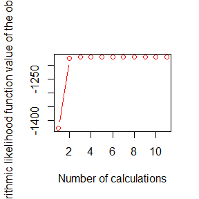

```r
plot(R[1:(k-1)],type='b',col='red',xlab="Number of calculations",ylab="The logarithmic likelihood function value of the observed data")
```

It can be seen that the corresponding values of the three parameters should be 0.3, 0.1, 0.6, and the logarithmic likelihood function value corresponding to the observed data is increasing

## Exercise 3

Use both for loops and lapply() to fit linear models to the mtcars using the formulas stored in this list:

formulas <- list(

mpg ~ disp,

mpg ~ I(1 / disp),

mpg ~ disp + wt,

mpg ~ I(1 / disp) + wt

)

## answer

The code and the corresponding two programming results are as follows:

```r
formulas <- list(
  mpg ~ disp,
  mpg ~ I(1 / disp),
  mpg ~ disp + wt,
  mpg ~ I(1 / disp) + wt
)

# lapply
L1<- lapply(formulas, lm, data = mtcars)
L2<- lapply(formulas, function(x) lm(formula = x, data = mtcars))

# circulation
L3 <- vector("list", length(formulas))
n<-seq_along(formulas)
for (i in n){
  L3[[i]] <- lm(formulas[[i]], data = mtcars)
}

print("The results of lapply:")
```

```
## [1] "The results of lapply:"
```

```r
print(L1)
```

```
## [[1]]
##
## Call:
## FUN(formula = X[[i]], data = ..1)
##
## Coefficients:
## (Intercept)         disp
##    29.59985     -0.04122
##
##
## [[2]]
##
## Call:
## FUN(formula = X[[i]], data = ..1)
##
## Coefficients:
## (Intercept)    I(1/disp)
##       10.75      1557.67
##
##
## [[3]]
##
## Call:
## FUN(formula = X[[i]], data = ..1)
##
## Coefficients:
## (Intercept)         disp           wt
##    34.96055     -0.01772     -3.35083
##
##
## [[4]]
##
## Call:
## FUN(formula = X[[i]], data = ..1)
##
## Coefficients:
## (Intercept)    I(1/disp)           wt
##      19.024     1142.560       -1.798
```

```r
print("The results of loop:")
```

```
## [1] "The results of loop:"
```

```r
print(L3)
```

```
## [[1]]
##
## Call:
## lm(formula = formulas[[i]], data = mtcars)
##
## Coefficients:
## (Intercept)         disp
##    29.59985     -0.04122
##
##
## [[2]]
##
## Call:
## lm(formula = formulas[[i]], data = mtcars)
##
## Coefficients:
## (Intercept)    I(1/disp)
##       10.75      1557.67
##
##
## [[3]]
##
## Call:
## lm(formula = formulas[[i]], data = mtcars)
##
## Coefficients:
## (Intercept)         disp           wt
##    34.96055     -0.01772     -3.35083
##
##
## [[4]]
##
## Call:
## lm(formula = formulas[[i]], data = mtcars)
##
## Coefficients:
## (Intercept)    I(1/disp)           wt
##      19.024     1142.560       -1.798
```

The result is as above.

## Exercise 3

The following code simulates the performance of a t-test for non-normal data. Use sapply() and an anonymous function to extract the p-value from every trial.

trials <- replicate(

100,

t.test(rpois(10, 10), rpois(7, 10)),

simplify = FALSE

)

Extra challenge: get rid of the anonymous function by using [[ directly.

## answer

The programming and results with the $sapply()$ and without anonymous functions are as follows:

```r
trials <- replicate(
  100,
  t.test(rpois(10, 10), rpois(7, 10)),
  simplify = FALSE
)

# Using sapply () and anonymous functions:
sapply(trials, function(x) x[["p.value"]])
```

```
##   [1] 0.203231124 0.666852171 0.899476698 0.494262937 0.633756213 0.259817041
##   [7] 0.677802156 0.252023681 0.465450392 0.137496320 0.627775122 0.472396288
##  [13] 0.500586904 0.314944349 0.814916092 0.211391578 0.878079681 0.754907874
##  [19] 0.210565623 0.436571844 0.789176978 0.504795946 0.665214496 0.603544371
##  [25] 0.947606945 0.457150800 0.326773695 0.582785060 0.687992935 0.514933523
##  [31] 0.149496960 0.856761666 0.963781549 0.408786094 0.287050729 0.522960868
##  [37] 0.123086747 0.648054275 0.187952157 0.913154874 0.617853124 0.467126587
##  [43] 0.857384013 0.269193593 0.873978062 0.888009651 0.560975381 0.752105777
##  [49] 0.295425798 0.765824724 0.617025824 0.792403720 0.004185347 0.138323951
##  [55] 0.386630810 0.127810348 0.216266222 0.914687599 0.737307338 0.053613310
##  [61] 0.289148263 0.884816305 0.865016381 0.165787044 0.687896752 0.272062869
##  [67] 0.318186250 0.607633931 0.251405928 0.692040522 0.674261402 0.897868274
##  [73] 0.427955171 0.216693283 0.548097371 0.528989743 0.739396934 0.653777703
##  [79] 0.546358023 0.984705121 0.736965441 0.587989034 0.219107990 0.647580135
##  [85] 0.065676900 0.117300765 0.340376957 0.696616406 0.275659726 0.250473947
##  [91] 0.665218729 0.611339688 0.172585161 0.005448479 0.262703435 0.167187750
##  [97] 0.200757285 0.232045979 0.839962929 0.379383652
```

```r
# Do not use anonymous functions:
sapply(trials, "[[", "p.value")
```

```
##   [1] 0.203231124 0.666852171 0.899476698 0.494262937 0.633756213 0.259817041
##   [7] 0.677802156 0.252023681 0.465450392 0.137496320 0.627775122 0.472396288
##  [13] 0.500586904 0.314944349 0.814916092 0.211391578 0.878079681 0.754907874
##  [19] 0.210565623 0.436571844 0.789176978 0.504795946 0.665214496 0.603544371
##  [25] 0.947606945 0.457150800 0.326773695 0.582785060 0.687992935 0.514933523
##  [31] 0.149496960 0.856761666 0.963781549 0.408786094 0.287050729 0.522960868
##  [37] 0.123086747 0.648054275 0.187952157 0.913154874 0.617853124 0.467126587
##  [43] 0.857384013 0.269193593 0.873978062 0.888009651 0.560975381 0.752105777
##  [49] 0.295425798 0.765824724 0.617025824 0.792403720 0.004185347 0.138323951
##  [55] 0.386630810 0.127810348 0.216266222 0.914687599 0.737307338 0.053613310
##  [61] 0.289148263 0.884816305 0.865016381 0.165787044 0.687896752 0.272062869
##  [67] 0.318186250 0.607633931 0.251405928 0.692040522 0.674261402 0.897868274
##  [73] 0.427955171 0.216693283 0.548097371 0.528989743 0.739396934 0.653777703
##  [79] 0.546358023 0.984705121 0.736965441 0.587989034 0.219107990 0.647580135
##  [85] 0.065676900 0.117300765 0.340376957 0.696616406 0.275659726 0.250473947
##  [91] 0.665218729 0.611339688 0.172585161 0.005448479 0.262703435 0.167187750
##  [97] 0.200757285 0.232045979 0.839962929 0.379383652
```

## Exercise 6

Implement a combination of Map() and vapply() to create an lapply() variant that iterates in parallel over all of its inputs and stores its outputs in a vector (or a matrix). What arguments should the function take?

## answer

The data sets $iris,mtcars,cars$are used

The program is as follows:

```r
testlist <- list(iris, mtcars, cars)

lapply(testlist, function(x) vapply(x, mean, numeric(1)))
```

```
## [[1]]
## Sepal.Length  Sepal.Width Petal.Length  Petal.Width      Species
##     5.843333     3.057333     3.758000     1.199333           NA
##
## [[2]]
##        mpg        cyl       disp         hp       drat         wt       qsec
##  20.090625   6.187500 230.721875 146.687500   3.596563   3.217250  17.848750
##         vs         am       gear       carb
##   0.437500   0.406250   3.687500   2.812500
##
## [[3]]
## speed  dist
## 15.40 42.98
```

```r
lmapply <- function(X, FUN, FUN.VALUE, simplify = FALSE){
  out <- Map(function(x) vapply(x, FUN, FUN.VALUE), X)
  if(simplify == TRUE){return(simplify2array(out))}
  out
}

lmapply(testlist, mean, numeric(1))
```

```
## [[1]]
## Sepal.Length  Sepal.Width Petal.Length  Petal.Width      Species
##     5.843333     3.057333     3.758000     1.199333           NA
##
## [[2]]
##        mpg        cyl       disp         hp       drat         wt       qsec
##  20.090625   6.187500 230.721875 146.687500   3.596563   3.217250  17.848750
##         vs         am       gear       carb
##   0.437500   0.406250   3.687500   2.812500
##
## [[3]]
## speed  dist
## 15.40 42.98
```

The parameters taken by the function are showed in the programming function lmapply above.

## Question

1.1 Write an Rcpp function for Exercise 9.4 (page 277, Statistical Computing with R).

1.3 Compare the computation time of the two functions with the function “microbenchmark”.

1.4 Comments your results.

## answer

The code is as follows:

```r
library(Rcpp)
dir_cpp <- '../src/'
#Can create source file in Rstudio
sourceCpp(paste0(dir_cpp,"Metropolis.cpp"))
#library(StatComp20091)
library(microbenchmark)
```

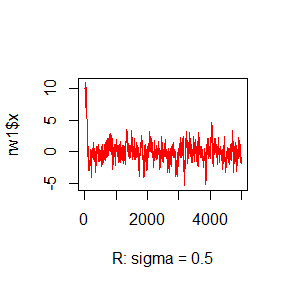

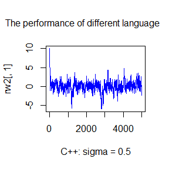

```
## [1] "when sigma= 0.5 ,the running time of the corresponding two cases is:"
##                                    expr       lq   median       uq
## 1 rw1 <- rw.Metropolis(sigma[i], x0, N) 13026.75 13695.90 17623.95
## 2    rw2 <- Metropolis(sigma[i], x0, N)   522.75   548.65   561.20
## [1] "The normal standard deviation of the first chain in R is: 0.5 ,accept rate is : 0.8214 ;"
## [1] "The normal standard deviation of the first chain in C++: 0.5 ,accept rate is : 0.8328"
```

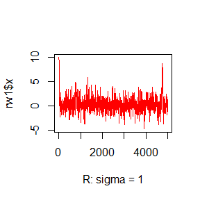

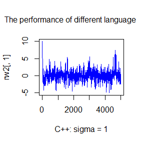

```
## [1] "when sigma= 1 ,the running time of the corresponding two cases is:"
##                                    expr       lq   median       uq
## 1 rw1 <- rw.Metropolis(sigma[i], x0, N) 13139.35 13849.75 17232.60
## 2    rw2 <- Metropolis(sigma[i], x0, N)   529.25   539.90   559.05
## [1] "The normal standard deviation of the first chain in R is: 1 ,accept rate is : 0.7052 ;"
## [1] "The normal standard deviation of the first chain in C++: 1 ,accept rate is : 0.6924"
```

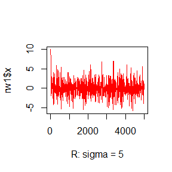

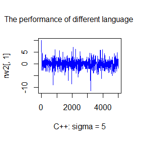

```
## [1] "when sigma= 5 ,the running time of the corresponding two cases is:"
##                                    expr       lq  median      uq
## 1 rw1 <- rw.Metropolis(sigma[i], x0, N) 12956.75 13703.3 17213.4
## 2    rw2 <- Metropolis(sigma[i], x0, N)   474.55   489.1   501.8
## [1] "The normal standard deviation of the first chain in R is: 5 ,accept rate is : 0.2846 ;"
## [1] "The normal standard deviation of the first chain in C++: 5 ,accept rate is : 0.2862"
```

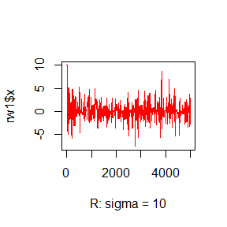

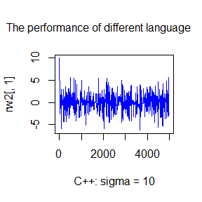

```
## [1] "when sigma= 10 ,the running time of the corresponding two cases is:"
##                                    expr      lq  median      uq
## 1 rw1 <- rw.Metropolis(sigma[i], x0, N) 12325.0 12884.0 16167.9
## 2    rw2 <- Metropolis(sigma[i], x0, N)   441.9   446.3   453.2
## [1] "The normal standard deviation of the first chain in R is: 10 ,accept rate is : 0.154 ;"
## [1] "The normal standard deviation of the first chain in C++: 10 ,accept rate is : 0.1692"
```

```r
LSR<-function(x){
  f<-exp(-abs(x))/2
  return(f)
}

rw.Metropolis<-function(sigma,x0,N){
  x<-numeric(N)
  x[1]<-x0
  u<-runif(N)
  k<-0
  for (i in 2:N){
    y<-rnorm(1,x[i-1],sigma)
    if (u[i] <= LSR(y) / LSR(x[i-1]))
    {x[i] <- y}
    else
    {x[i] <- x[i-1]
    k<-k+1
    }
  }
  return(list(x=x,k=k))
}


N<-5000
sigma<-c(0.5,1,5,10)
x0<-10
lk<-matrix(rep(0,length(sigma)*2),ncol=2)

for ( i in c(1,2,3,4)){
  ts<-microbenchmark(rw1<-rw.Metropolis(sigma[i],x0,N),rw2<-Metropolis(sigma[i],x0,N))



  #par(mfrow = c(1, 2))
  plot(rw1$x,type='l',col='red',xlab=paste('R:',expression(sigma),'=',sigma[i]))
  plot(rw2[,1],type='l',col='blue',xlab=paste('C++:',expression(sigma),'=',sigma[i]))

  mtext("The performance of different language ", side =3, line = -2.5, outer = TRUE)
   print(paste('when sigma=',sigma[i],',the running time of the corresponding two cases is:'))
  RS<-summary(ts)[,c(1,3,5,6)]
  print(RS)
  lk[i,]<-(c(N-(rw1$k),N-rw2[1,3]))/N#Accept rate

  print(paste('The normal standard deviation of the first chain in R is:',sigma[i],',accept rate is :',lk[i,1],';'))
  print(paste('The normal standard deviation of the first chain in C++:',sigma[i],',accept rate is :',lk[i,2]))

}
```

It can be seen from the four cases that the computing time is basically more than 20 times of that of C++.